# Data Mining and Text Mining Final Project

Analysis of 2017 Boston Marathon Data

Ethan Bard, ebard4264@floridapoly.edu

### Introduction

Since 1897, the Boston Marathon is an annual marathon race hosted by several cities in the Boston area of Massachusetts. Since 2001, the Boston Athletic Association (BAA) has been recording and publicly providing data about runners who successfully finish the marathon. People of all different age groups, sex, and national origins come to compete in this marathon every year and it is always interesting to see who comes out on top. In the following analysis, the data set containing results of the 2017 Boston Marathon will be explored using various data mining techniques in an attempt to learn more about these athletes.

### Exploratory Analysis

The data set used in this analysis was compiled and provided by Dr. Reinaldo Sanchez-Arias. To begin the analysis, the data is loaded into R and an initial exploratory analysis is performed. Before performing any further analysis, a general understanding of the data must be obtained.

```r
#Import libraries
library(tidyverse)
library(dplyr)
library(ggplot2)
library(ggfortify)
library(factoextra)
```

```r
data <- read_csv("https://raw.githubusercontent.com/reisanar/datasets/master/marathon_results_2017.csv")
```

```
158 parsing failures.
 row  col   expected actual                                                                                   file
1390 35K  time like       - 'https://raw.githubusercontent.com/reisanar/datasets/master/marathon_results_2017.csv'
1546 35K  time like       - 'https://raw.githubusercontent.com/reisanar/datasets/master/marathon_results_2017.csv'
2132 20K  time like       - 'https://raw.githubusercontent.com/reisanar/datasets/master/marathon_results_2017.csv'
2132 Half time like       - 'https://raw.githubusercontent.com/reisanar/datasets/master/marathon_results_2017.csv'
2132 35K  time like       - 'https://raw.githubusercontent.com/reisanar/datasets/master/marathon_results_2017.csv'
.... .... .......... ...... ......................................................................................
See problems(...) for more details.
```

During the import process, there appear to be some parsing failures related to the column data types. This will be kept in mind while moving forward with the analysis.

```r
colnames(data)
```

```
 [1] "Bib"           "Name"          "Age"           "M/F"           "City"          "State"         "Country"       "5K"
 [9] "10K"           "15K"           "20K"           "Half"          "25K"           "30K"           "35K"           "40K"
[17] "Pace"          "Proj Time"     "Official Time" "Overall"       "Gender"        "Division"
```

The column names included in the data set are presented above. Most of the attributes are time recordings at different intervals of the marathon, but data is also present regarding the athlete’s age, sex, home country and/or state, and their official time.

Check the summary statistics of each attributes:

```r
summary(data)
```

```
     Bib                Name                Age            M/F                City              State             Country
 Length:26410       Length:26410       Min.   :18.00   Length:26410       Length:26410       Length:26410       Length:26410
 Class :character   Class :character   1st Qu.:34.00   Class :character   Class :character   Class :character   Class :character
 Mode  :character   Mode  :character   Median :43.00   Mode  :character   Mode  :character   Mode  :character   Mode  :character
                                       Mean   :42.59
                                       3rd Qu.:51.00
                                       Max.   :84.00
      5K               10K               15K                20K               Half              25K                30K
 Length:26410      Length:26410      Length:26410       Length:26410      Length:26410      Length:26410       Length:26410
 Class1:hms        Class1:hms        Class :character   Class1:hms        Class1:hms        Class :character   Class :character
 Class2:difftime   Class2:difftime   Mode  :character   Class2:difftime   Class2:difftime   Mode  :character   Mode  :character
 Mode  :numeric    Mode  :numeric                       Mode  :numeric    Mode  :numeric


     35K               40K               Pace           Proj Time         Official Time        Overall          Gender         Division
 Length:26410      Length:26410      Length:26410      Length:26410       Length:26410      Min.   :    1   Min.   :    1   Min.   :   1
 Class1:hms        Class1:hms        Class1:hms        Class :character   Class1:hms        1st Qu.: 6604   1st Qu.: 3302   1st Qu.: 502
 Class2:difftime   Class2:difftime   Class2:difftime   Mode  :character   Class2:difftime   Median :13206   Median : 6604   Median :1154
 Mode  :numeric    Mode  :numeric    Mode  :numeric                       Mode  :numeric    Mean   :13206   Mean   : 6661   Mean   :1589
                                                                                            3rd Qu.:19809   3rd Qu.: 9905   3rd Qu.:2191
                                                                                            Max.   :26411   Max.   :14438   Max.   :5846
```

According to the summary above, most of the attributes are of class type “hms” for time recordings, or “character” for personal information. For some reason, the columns 15k, 25k, and 30k are of class “character” as well, which could result in errors if this is not addressed. Additionally, it is not extremely clear what the ‘Gender’ and ‘Division’ attributes are meant to represent, so they will likely be removed from this analysis for clarity.

#### Exploratory Visualizations

```r
#rename columns to work with more easily
data <- data %>%
  rename(Sex = 'M/F',
         Official_time = 'Official Time')
```

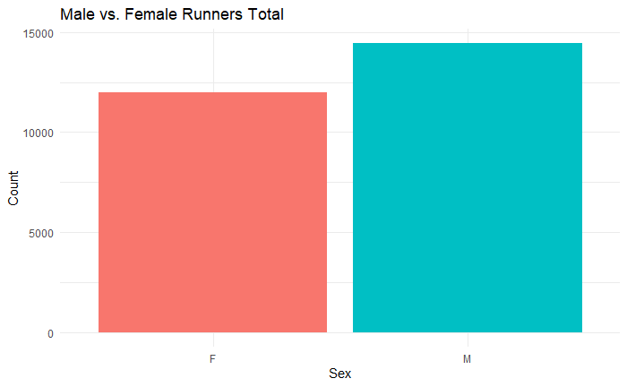

```r
#Count of male vs female runners
ggplot(data = data, aes(x = Sex, fill = Sex)) +
  geom_bar(stat = "count", show.legend = FALSE) +
  labs(title = "Male vs. Female Runners Total", x = "Sex", y = "Count") +
  theme_minimal()
```

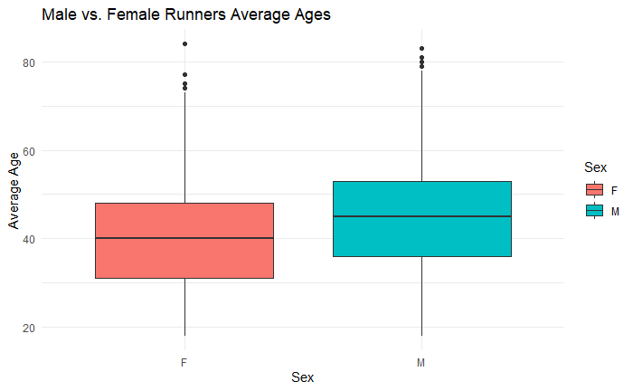

```r
#Average age of males vs females
ggplot(data = data, aes(x = Sex, y = Age, fill = Sex)) +
  geom_boxplot() +
  labs(title = "Male vs. Female Runners Average Ages", x = "Sex", y = "Average Age") +
  theme_minimal()
```

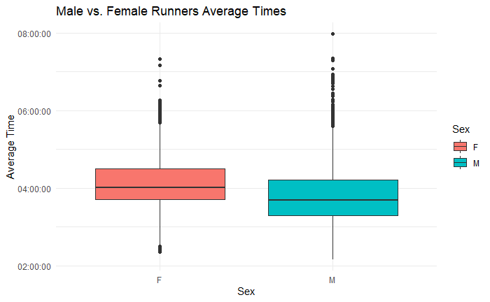

```r
#Average times of males vs females
ggplot(data = data, aes(x = Sex, y = Official_time, fill = Sex)) +
  geom_boxplot() +
  labs(title = "Male vs. Female Runners Average Times", x = "Sex", y = "Average Time") +
  theme_minimal()
```

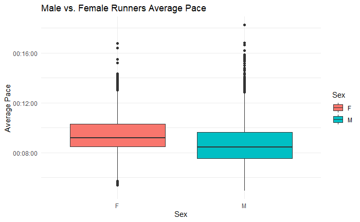

```r
#Average pace of males vs females
ggplot(data = data, aes(x = Sex, y = Pace, fill = Sex)) +
  geom_boxplot() +
  labs(title = "Male vs. Female Runners Average Pace", x = "Sex", y = "Average Pace") +
  theme_minimal()
```

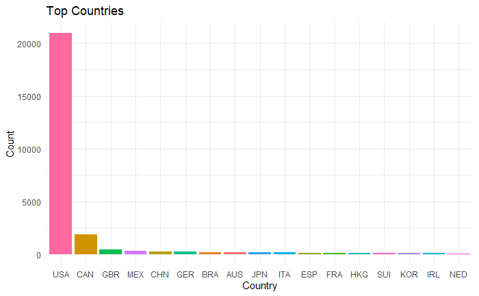

```r
#Country of Origin
data %>%
  count(.,Country) %>%
  arrange(desc(n)) %>%
  filter(n > 75) %>%
  ggplot(.,aes(x = reorder(factor(Country), -n), y = n, fill = Country)) +
  geom_bar(stat = "identity", show.legend = FALSE) +
  labs(title = "Top Countries", x = "Country", y = "Count") +
  theme_minimal()
```

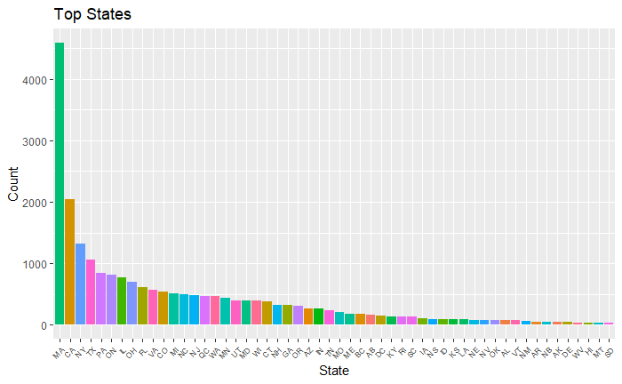

```r
#State of Origin
data %>%
  count(.,State) %>%
  arrange(desc(n)) %>%
  filter(State != 'NA', n > 30) %>%
  ggplot(.,aes(x = reorder(State, -n), y = n, fill = State)) +
  geom_bar(stat = "identity", show.legend = FALSE) +
  labs(title = "Top States", x = "State", y = "Count") +
  theme(axis.text.x=element_text(angle = 45, hjust =1, size =7))
```

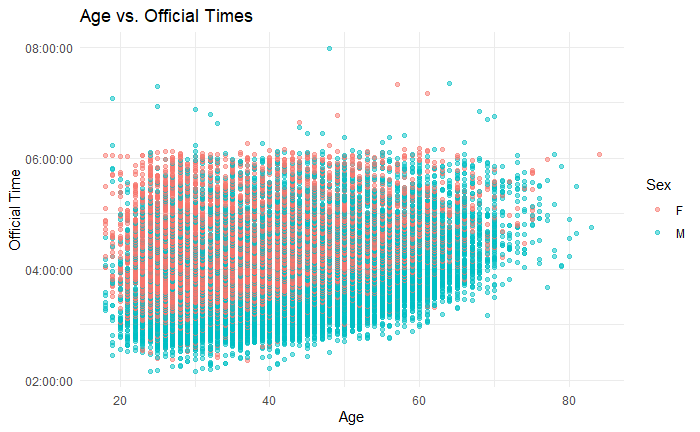

```r
ggplot(data = data,
       aes(x = Age,
           y = Official_time,
           color = Sex)) +
  geom_point(alpha = 0.5) +
  theme_minimal() +
  labs(title = "Age vs. Official Times", y = "Official Time")
```

The above visualizations reveal significant information about the population recorded in the dataset. The vast majority of the runners participating in the Boston Marathon in 2017 were from the USA, and of those from the USA the most popular states are MA, CA, NY, and TX. When comparing the performance of runners by sex, it appears that males on average complete the race with a shorter official time than females, and also have a faster pace on average. Additionally, there does not appear to be a significantly obvious visual correlation between age and official time.

For the next section of this analysis, Principal Component Analysis will be performed in order to reduce the dimensionality of the dataset before performing Clustering.